# Obesidad

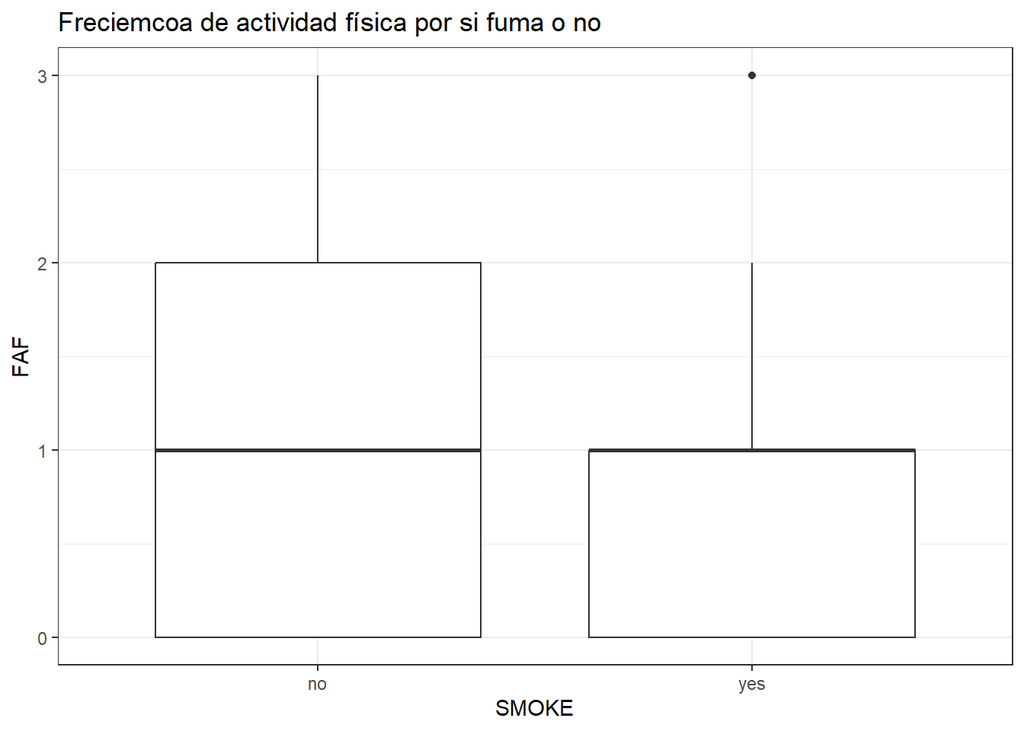

```r
train |>
  ggplot(aes(x = SMOKE, y = FAF)) +
  geom_boxplot() +
  theme_bw() +
  labs(title = "Freciemcoa de actividad física por si fuma o no")
```

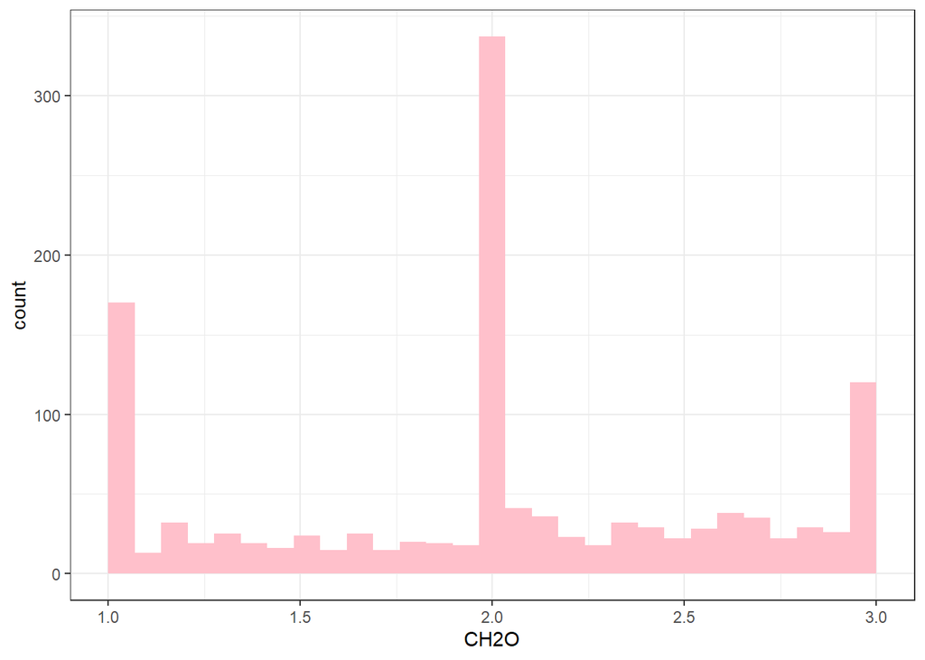

```r
train |>
  ggplot(aes(x = CH2O)) +
  geom_histogram(fill = "pink", bins = 30) +
  theme_bw()
```

Viendo el consumo de agua que tiene las personas, se ve como la mayoría de ellas consumen 2L al día, por lo que me pregunto la relación que tiene con la actividad física y con el nivel de obesidad.

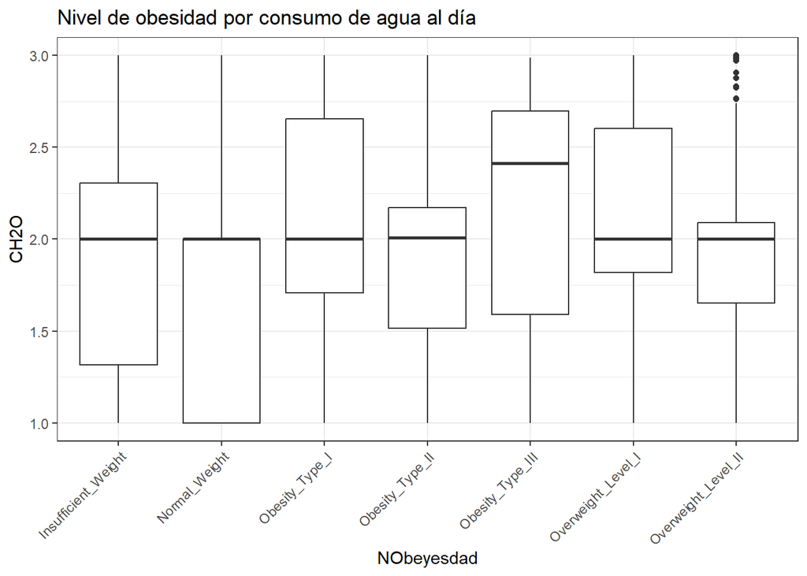

```r
train |>
  ggplot(aes(x = NObeyesdad, y = CH2O)) +
  geom_boxplot() +
  theme_bw() +
  labs(title = "Nivel de obesidad por consumo de agua al día") +
  theme(axis.text.x = element_text(angle = 45, hjust = 1))
```

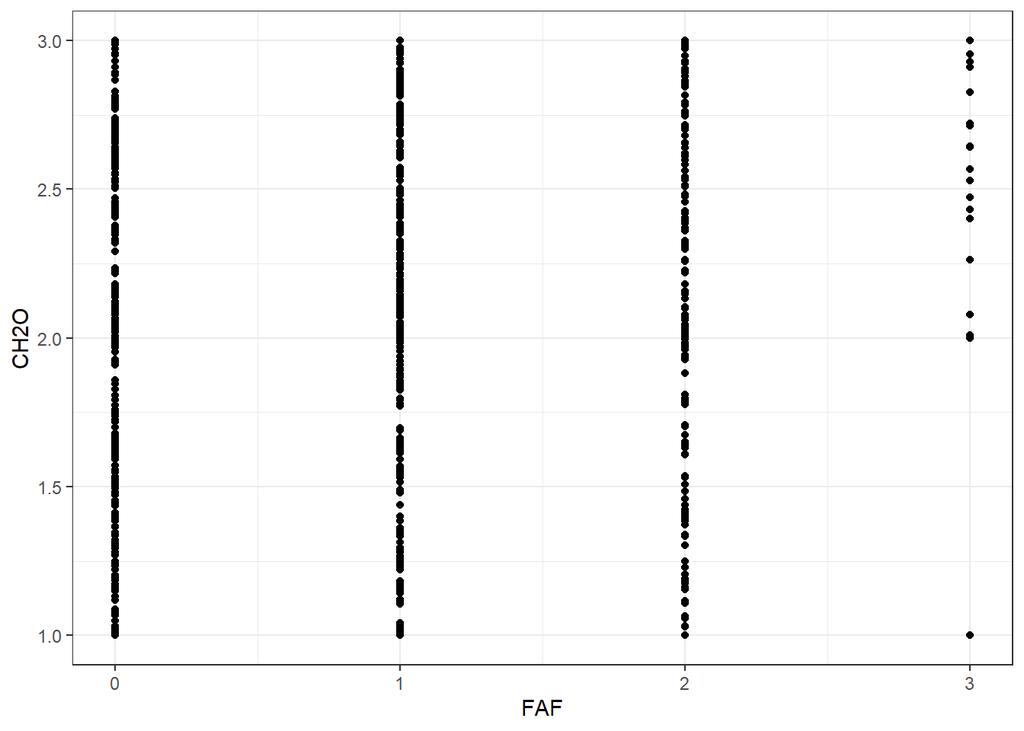

```r
train |>
  ggplot(aes(x = FAF, y = CH2O)) +
  geom_point() +
  theme_bw()
```

En las personas que entrenan 0, 1 o 2 días a la semana se ven datos que no me sorprenden por la cantidad de personas que hay en cada uno, sin embargo, las personas que entrenana 3 días a la semana benben como mínimo 2 L al día, por otro lado hay valores atípicos, como una persona que entrena 3 días y bebe 1L. A continuación vamos a ver si las personas se cuentan las calorias que consumen o no.

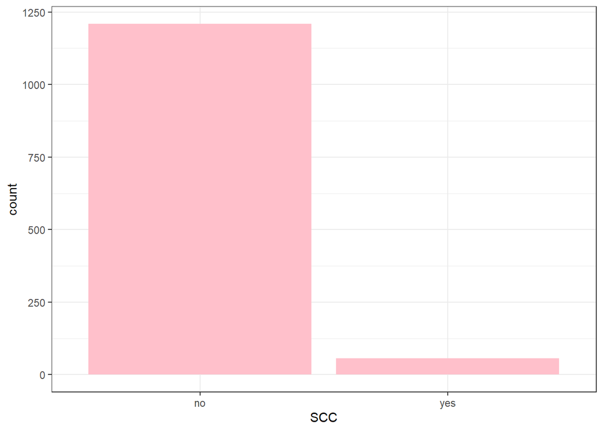

```r
train |>
  ggplot(aes(x = SCC)) +
  geom_bar(fill = "pink") +
  theme_bw()
```

Por lo que se ve la mayoría de las personas de las que se ha hecho el estudio no se cuentan las calorías que consumen, por lo que vamos a ver si esto tiene relación con el nivel de obesidad de las personas.

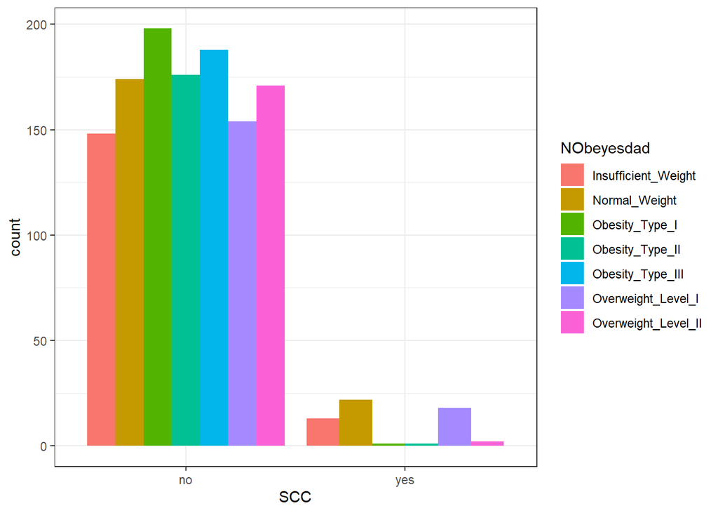

```r
train |>
  ggplot(aes(x = SCC, fill = NObeyesdad)) +
  geom_bar(position = "dodge") +
  theme_bw()
```

Como se ve las personas que si que se cuentan las calorías, la mayoría de las personas tienen peso normal, por otro lado, las personas que no se cuentan las calorías han desarrollado algún tipo de obesidad, obre todo obesidad de tipo I y obesidad de tipo III.

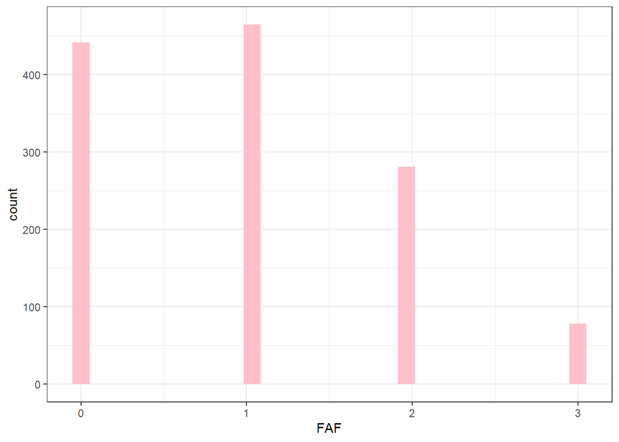

```r
train |>
  ggplot(aes(x = FAF)) +
  geom_histogram(fill = "pink", bins = 30) +
  theme_bw()
```

Vamos a ver que relación tiene con el nivel de obesidad de las personas con la frecuencia de actividad física que hacen a la semana.

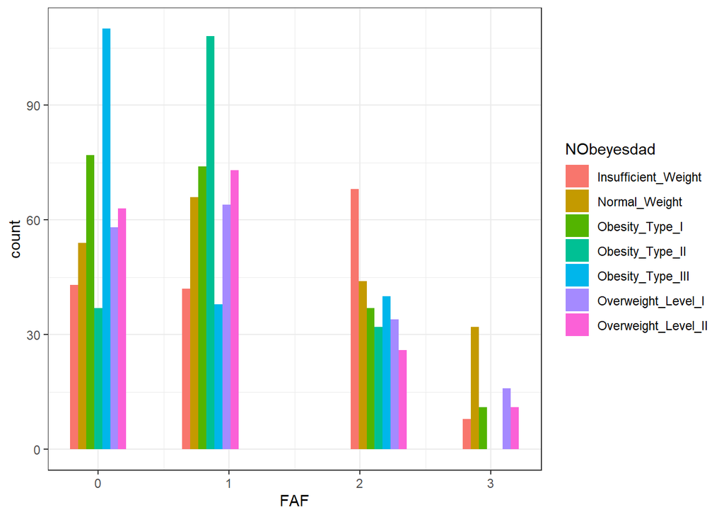

```r
train |>
  ggplot(aes(x = FAF, fill = NObeyesdad)) +
  geom_histogram(position = "dodge", bins = 8) +
  theme_bw()
```

Podemos ver ue las personas que entrenan o que entrenan un día, es más probable que desarrollen algún tipo de obesidad, sin embargo, las personas que entrenan 3 días, la mayoría tienen peso normal, así como las personas que entrenan 2 la mayoría tiene peso insuficiente.

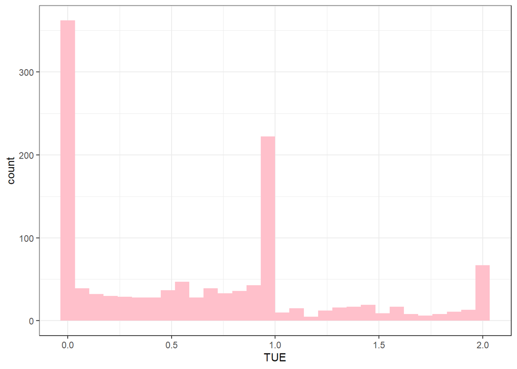

```r
train |>
  ggplot(aes(x = TUE)) +
  geom_histogram(fill = "pink", bins = 30) +
  theme_bw()
```

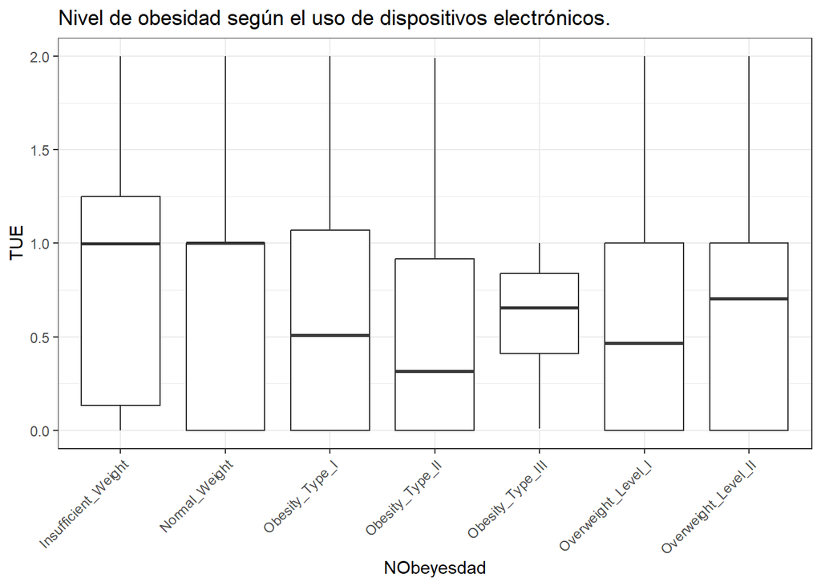

```r
train |>
  ggplot(aes(x = NObeyesdad, y = TUE)) +
  geom_boxplot() +
  theme_bw() +
  labs(title = "Nivel de obesidad según el uso de dispositivos electrónicos.") +
  theme(axis.text.x = element_text(angle = 45, hjust = 1))
```

Mirando el nivel de obesidad por el tiempo que se usan dispositivos electronicos, se puede ver que en proedio, las personas que más están con el movil con las que tienen peso noemal o peso insuficiente.

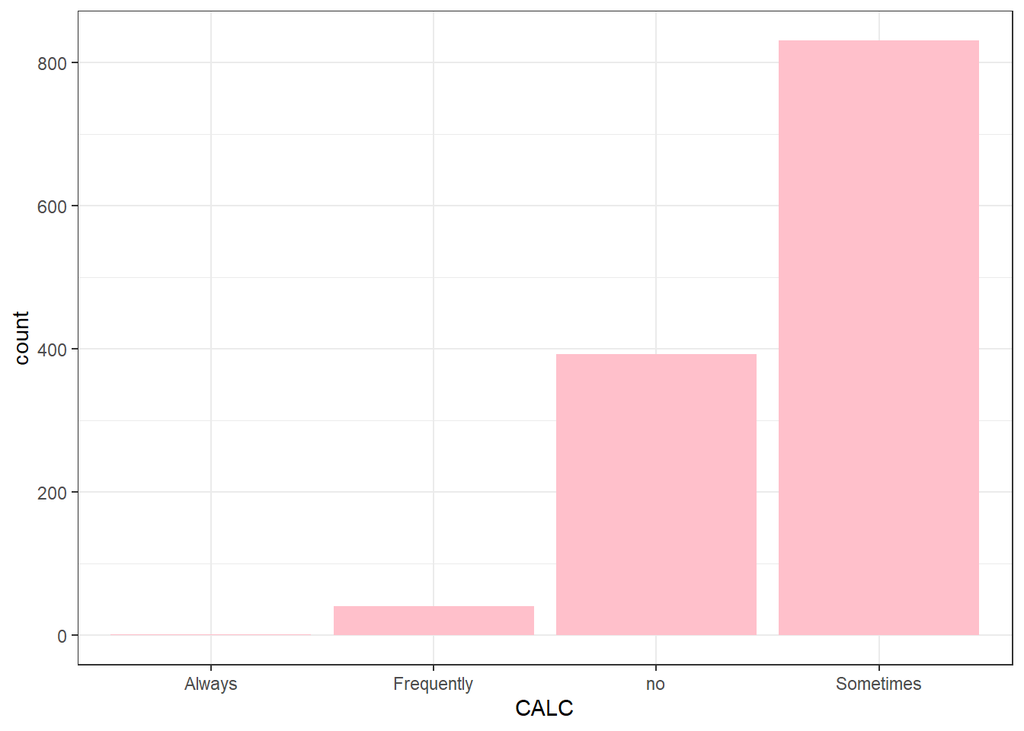

```r
train |>
  ggplot(aes(x = CALC)) +
  geom_bar(fill = "pink") +
  theme_bw()
```

Como vemos en la distribución, la mayoría de personas de estos datos toman alcohol de vez en cuando, sin embargo tenemos a una persona que toma alcohol siempre, por lo que vamos a ver que relación hay entre tomar alcohol y el nivel de obesidad, la cantidad de agua que se toma y la frecuencia de actividad física.

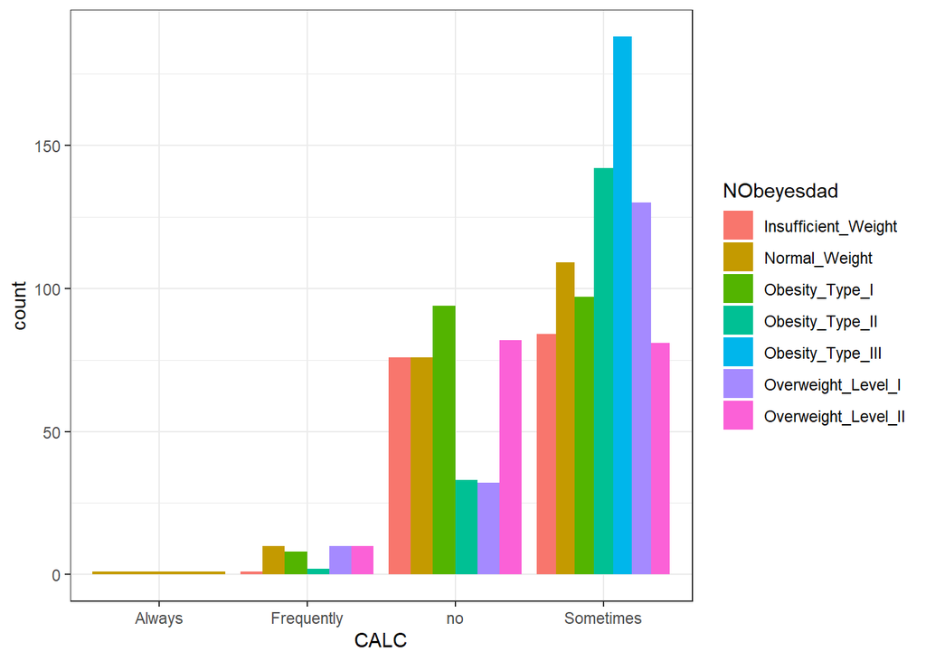

```r
train |>
  ggplot(aes(x = CALC, fill = NObeyesdad)) +
  geom_bar(position = "dodge") +
  theme_bw()
```

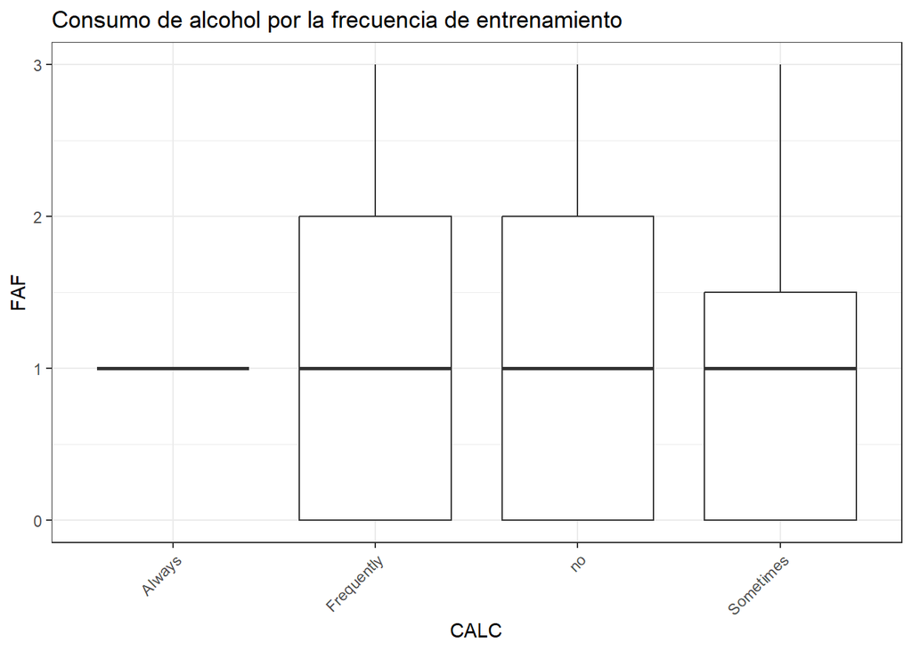

```r
train |>
  ggplot(aes(x = CALC, y = FAF)) +
  geom_boxplot() +
  theme_bw() +
  labs(title = "Consumo de alcohol por la frecuencia de entrenamiento") +
  theme(axis.text.x = element_text(angle = 45, hjust = 1))
```

Al mirar el gráfico, se puede ver que en media las personas que no toman alcohol o que lo toman frecuentemente, hacen más ejercicio que los otros dos grupos, sin embargo, la media de los grupos esta en hacer ejercicio 1 día a la semana.

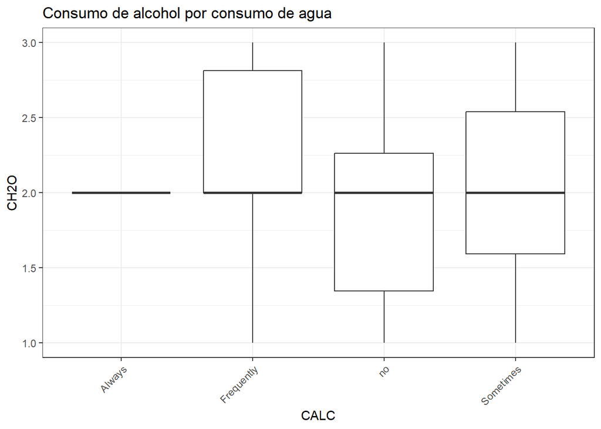

```r
train |>
  ggplot(aes(x = CALC, y = CH2O)) +
  geom_boxplot() +
  theme_bw() +
  labs(title = "Consumo de alcohol por consumo de agua") +
  theme(axis.text.x = element_text(angle = 45, hjust = 1))
```

POdemos ver cierta relación entre las personas que consumen alcohol y las que no, por lo que se ve, en promedio, cuanto más alcohol se consume, más agua se toma. Sin embargo, como hemos visto antes la media está en que las personas consumen 2L de agua al día. Los medios de transporte utilizados por las personas también pueden afectar al nivel de obesidad ya que pueden suponer más o menos actividad física, veremos la frecuencia de cada uno para más adelante analizarlos en función de los niveles de obesidad:

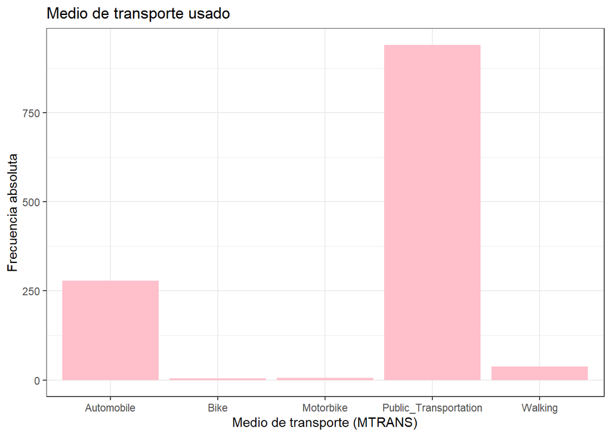

```r
train|>
  ggplot(aes(x = MTRANS)) +
  geom_bar(fill = "pink") +
  theme_bw() +
  labs(title = "Medio de transporte usado",
       x = "Medio de transporte (MTRANS)",
       y = "Frecuencia absoluta")
```

Como vemos la mayor parte de las personas utilizan el transporte público como medio de transporte, por lo que vamos a ver su relación el nivel de obesidad. Ahora agrupamos la categoria Mtrans (que asigna el medio de transporte que usan las personas de la muestra) en los que van andando y los que van en transporte, para ver como afecta el movimiento a la obesidad.

```r
# Crear la nueva variable de transporte
obesidad_transp <- train %>%
  mutate(MTRANS_grouped = case_when(
    MTRANS %in% c("Automobile", "Motorbike", "Public_Transportation") ~ "No Walking",
    MTRANS %in% c("Walking", "Bike") ~ "Walking",
    TRUE ~ MTRANS # En caso de valores inesperados
  ))
```

Creamos un grafico para las personas que no van andando ni en bici y así poder visualizar su nivel de obesidad.

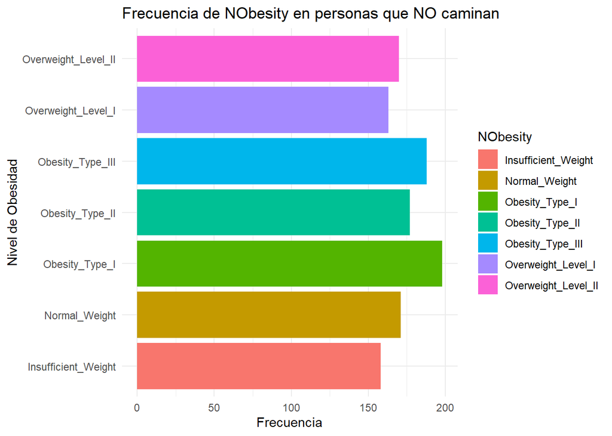

```r
#No Walking

ggplot(filter(obesidad_transp, MTRANS_grouped == "No Walking"), aes(y = NObeyesdad, fill = NObeyesdad)) +
  geom_bar(position = "dodge") +  # Barras separadas
  labs(y = "Nivel de Obesidad", x = "Frecuencia", fill = "NObesity") +
  ggtitle("Frecuencia de NObesity en personas que NO caminan") +
  theme_minimal()
```

Ahora, para las personas que andan, es decir que se mueven creamos otro gráfico para ver su nivel de obesidad.

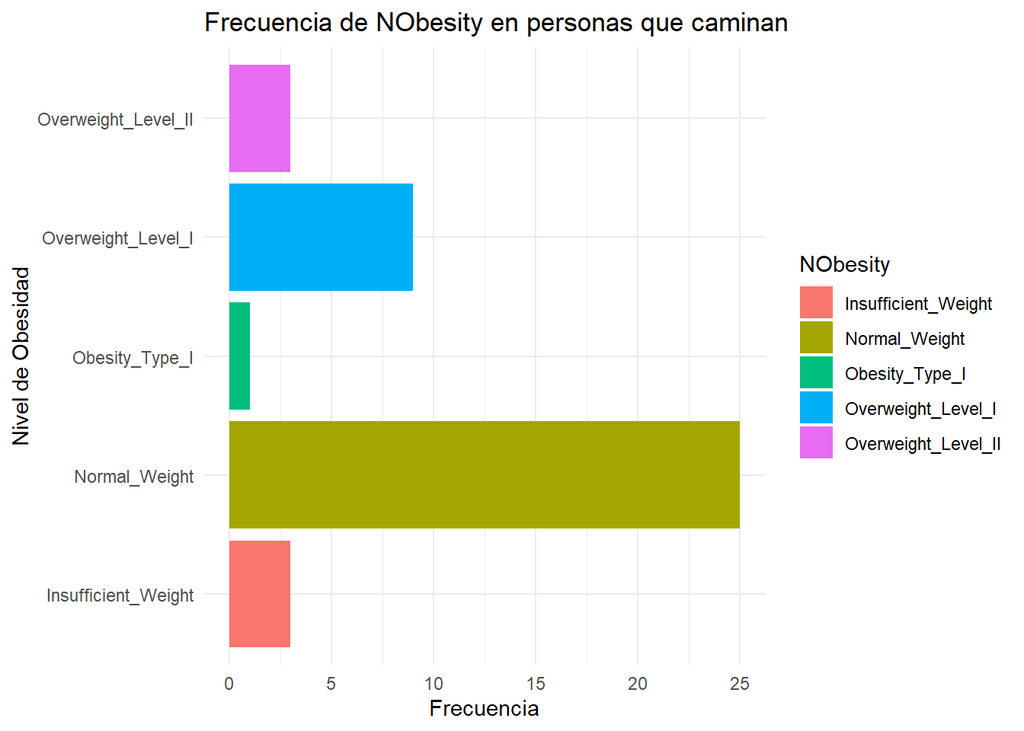

```r
# Walking
ggplot(filter(obesidad_transp, MTRANS_grouped == "Walking"), aes(y = NObeyesdad, fill = NObeyesdad)) +
  geom_bar(position = "dodge") +  # Barras separadas
  labs(y = "Nivel de Obesidad", x = "Frecuencia", fill = "NObesity") +
  ggtitle("Frecuencia de NObesity en personas que caminan") +
  theme_minimal()
```

El número de personas con obesidad dentro del grupo de las que no caminan es mucho mayor que en el grupo de las que sí caminan, ya que como se puede observar en el segundo gráfico (personas que sí caminan) el número de personas con peso normal (Normal_Weight) es muy elevado. Esto se ajusta y tiene sentido en la realidad, ya que el movimiento que una persona realiza en su día a día está directamente relacionado con tener un peso más o menos elevado.

# 3. PCA.

## Con la función prcomp() de R:

```r
ironman_lake_placid_female_2022 <- read_csv("C:/Users/laram/Downloads/archive (3)/ironman_lake_placid_female_2022.csv")
```

Ahora trabajaremos con un conjunto de datos sobre participantes femeninas en un triatlon Ironman, las variables que utilizaremos son, Swim.Time, Run.Time y Bike.Time, mediante la función head podemos observar la estructura del conjunto de datos y sus variables:

```r
head(ironman_lake_placid_female_2022)
```

```
## # A tibble: 6 × 17
##     Bib Name     Country Gender Division Division.Rank Overall.Time Overall.Rank
##   <dbl> <chr>    <chr>   <chr>  <chr>            <dbl>        <dbl>        <dbl>
## 1     3 Sarah T… United… Female FPRO                 1         540.           11
## 2     1 Heather… United… Female FPRO                 2         556.           13
## 3     8 Jodie R… United… Female FPRO                 3         562.           16
## 4     5 Rachel … United… Female FPRO                 4         573.           20
## 5     2 Melanie… Canada  Female FPRO                 5         575.           21
## 6    10 Angela … United… Female FPRO                 6         586.           28
## # ℹ 9 more variables: Swim.Time <dbl>, Swim.Rank <dbl>, Bike.Time <dbl>,
## #   Bike.Rank <dbl>, Run.Time <dbl>, Run.Rank <dbl>, Finish.Status <chr>,
## #   Location <chr>, Year <dbl>
```

Resumen estadístico de cada variable:

```r
summary(ironman_lake_placid_female_2022)
```

```
##       Bib           Name             Country             Gender
##  Min.   :   1   Length:489         Length:489         Length:489
##  1st Qu.: 551   Class :character   Class :character   Class :character
##  Median :1078   Mode  :character   Mode  :character   Mode  :character
##  Mean   :1107
##  3rd Qu.:1626
##  Max.   :2367
##
##    Division         Division.Rank     Overall.Time     Overall.Rank
##  Length:489         Min.   :  1.00   Min.   : 540.4   Min.   :  11
##  Class :character   1st Qu.: 13.00   1st Qu.: 777.0   1st Qu.: 579
##  Mode  :character   Median : 30.00   Median : 857.6   Median :1033
##                     Mean   : 34.25   Mean   : 849.3   Mean   :1003
##                     3rd Qu.: 51.00   3rd Qu.: 937.8   3rd Qu.:1455
##                     Max.   :155.00   Max.   :1041.4   Max.   :1816
##                     NA's   :1
##    Swim.Time         Swim.Rank      Bike.Time       Bike.Rank
##  Min.   :  50.95   Min.   :  10   Min.   :292.4   Min.   :  18
##  1st Qu.:  72.70   1st Qu.: 603   1st Qu.:392.8   1st Qu.: 726
##  Median :  81.47   Median :1183   Median :425.2   Median :1187
##  Mean   :  88.10   Mean   :1117   Mean   :424.8   Mean   :1136
##  3rd Qu.:  89.03   3rd Qu.:1626   3rd Qu.:459.5   3rd Qu.:1602
##  Max.   :3498.00   Max.   :2106   Max.   :531.4   Max.   :1995
##
##     Run.Time        Run.Rank      Finish.Status        Location
##  Min.   :184.1   Min.   :   7.0   Length:489         Length:489
##  1st Qu.:288.6   1st Qu.: 518.0   Class :character   Class :character
##  Median :324.1   Median : 942.0   Mode  :character   Mode  :character
##  Mean   :324.6   Mean   : 942.6
##  3rd Qu.:366.8   3rd Qu.:1397.0
##  Max.   :459.4   Max.   :1829.0
##
##       Year
##  Min.   :2022
##  1st Qu.:2022
##  Median :2022
##  Mean   :2022
##  3rd Qu.:2022
##  Max.   :2022
##
```

Observamos la estructura de dataset:

```r
str(ironman_lake_placid_female_2022)
```

```
## spc_tbl_ [489 × 17] (S3: spec_tbl_df/tbl_df/tbl/data.frame)
##  $ Bib          : num [1:489] 3 1 8 5 2 10 7 6 313 15 ...
##  $ Name         : chr [1:489] "Sarah True" "Heather Jackson" "Jodie Robertson" "Rachel Zilinskas" ...
##  $ Country      : chr [1:489] "United States" "United States" "United States" "United States" ...
##  $ Gender       : chr [1:489] "Female" "Female" "Female" "Female" ...
##  $ Division     : chr [1:489] "FPRO" "FPRO" "FPRO" "FPRO" ...
##  $ Division.Rank: num [1:489] 1 2 3 4 5 6 7 8 1 9 ...
##  $ Overall.Time : num [1:489] 540 556 562 573 575 ...
##  $ Overall.Rank : num [1:489] 11 13 16 20 21 28 33 35 39 40 ...
##  $ Swim.Time    : num [1:489] 55.6 65.4 62.9 51 58 ...
##  $ Swim.Rank    : num [1:489] 28 238 148 10 57 254 58 60 161 134 ...
##  $ Bike.Time    : num [1:489] 296 292 305 312 306 ...
##  $ Bike.Rank    : num [1:489] 21 18 33 47 35 36 60 23 97 86 ...
##  $ Run.Time     : num [1:489] 184 194 188 203 206 ...
##  $ Run.Rank     : num [1:489] 7 16 11 30 35 38 41 98 25 31 ...
##  $ Finish.Status: chr [1:489] "Finisher" "Finisher" "Finisher" "Finisher" ...
##  $ Location     : chr [1:489] "Lake Placid" "Lake Placid" "Lake Placid" "Lake Placid" ...
##  $ Year         : num [1:489] 2022 2022 2022 2022 2022 ...
##  - attr(*, "spec")=
##   .. cols(
##   ..   Bib = col_double(),
##   ..   Name = col_character(),
##   ..   Country = col_character(),
##   ..   Gender = col_character(),
##   ..   Division = col_character(),
##   ..   Division.Rank = col_double(),
##   ..   Overall.Time = col_double(),
##   ..   Overall.Rank = col_double(),
##   ..   Swim.Time = col_double(),
##   ..   Swim.Rank = col_double(),
##   ..   Bike.Time = col_double(),
##   ..   Bike.Rank = col_double(),
##   ..   Run.Time = col_double(),
##   ..   Run.Rank = col_double(),
##   ..   Finish.Status = col_character(),
##   ..   Location = col_character(),
##   ..   Year = col_double()
##   .. )
##  - attr(*, "problems")=<externalptr>
```

Como hemos mencionado previamente, las variables que usaremos para PCA son Swim.Time, Run.Time, y Bike.Time (tiempo en cada tipo de carrera), por lo tanto las seleccionamos:

```r
#Seleccionamos solo las variables necesarias para hacer el PCA, que son Swim.Time, Bike.Time y Run.Time
ironman_numeric <- ironman_lake_placid_female_2022[, c("Swim.Time", "Bike.Time", "Run.Time")]
```

```r
#Eliminamos filas con valores NA
ironman_numeric <- na.omit(ironman_numeric)

# Verificamos si hay valores NA
sum(is.na(ironman_numeric))
```

```
## [1] 0
```

```r
#Verificamos que no haya varianza cero en las columnas
ironman_numeric <- ironman_numeric[, sapply(ironman_numeric, function(col) var(col, na.rm = TRUE) > 0)]
```

Realizamos el análisis de componentes principales (PCA) que se basa en simplificar la estructura de datos, preservando al mismo tiempo la mayor cantidad posible de información. Este método convierte un grupo de variables originales en un conjunto nuevo de variables no correlacionadas llamadas componentes principales. Estas nuevas variables capturan la variabilidad presente en los datos de manera más eficiente.

Con la función prcomp realizamos el PCA:

```r
# Aplicar PCA con escalado
pca_result <- prcomp(ironman_numeric, scale. = TRUE)
```

```r
dim(pca_result$x)
```

```
## [1] 489   3
```

Nuestro PCA nos da un total de 3 componentes principales (PC1, PC2 Y PC3) y 489 atletas

Visualizamos la importancia relativa de cada componente:

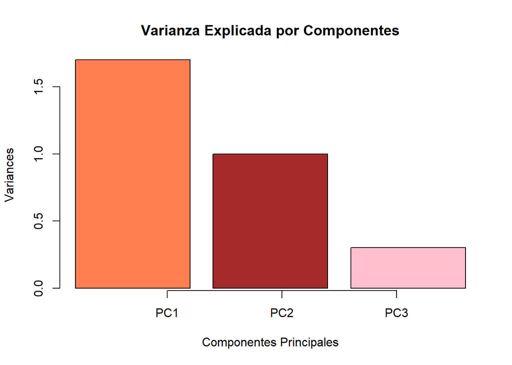

```r
pca_result <- prcomp(ironman_numeric, scale=T)

# Graficamos el PCA para observar la varianza que explica cada componente
plot(pca_result, col = c("coral", "brown", "pink"),
     main = "Varianza Explicada por Componentes",
     xlab = "Componentes Principales")


axis(1, at=1:3, labels=c("PC1", "PC2", "PC3"))
```

```r
summary(prcomp(ironman_numeric,scale=T))
```

```
## Importance of components:
##                           PC1    PC2    PC3
## Standard deviation     1.3043 0.9989 0.5486
## Proportion of Variance 0.5671 0.3326 0.1003
## Cumulative Proportion  0.5671 0.8997 1.0000
```

```r
#Desviaciones típicas de los autovalores
prcomp(ironman_numeric, scale=T)$sdev
```

```
## [1] 1.3043454 0.9988829 0.5485581
```

```r
#cantidad de variabilidad explicada por cada componente principal
```

Las desviaciones típicas explican también la cantidad de variabilidad explicada por cada componente principal y PC1 es la mayor y por tanto las que más explica.

Por tanto, las dos primeras componentes principales PC1 Y PC2, son suficientemente representativas como para realizar un gráfico de los datos con ellas, ya que explican la mayor parte de la varianza.

Continuamos representando la matriz de rotacion, cuyos valores muestran cuanto contribuye cada variable original a cada componente principal:

```r
# Rotation representa la matriz de rotacion
prcomp(ironman_numeric, scale=T)$rotation
```

```
##                   PC1         PC2         PC3
## Swim.Time -0.06643164 -0.99716374  0.03537393
## Bike.Time -0.70637297  0.02196078 -0.70749908
## Run.Time  -0.70471559  0.07198752  0.70582841
```

PC1 asigna pesos a las variables y como se ve en la matriz todas tienen un peso con el mismo signo lo que significa que hace un promedio ponderado de las variables principales.

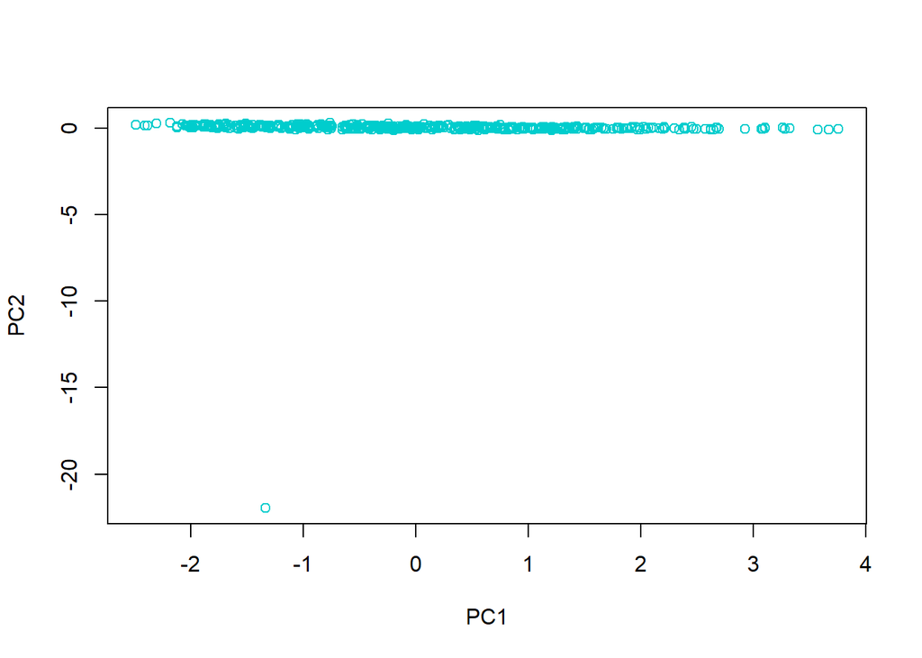

```r
plot(prcomp(ironman_numeric,scale=T)$x[,1:2], col = adjustcolor("cyan3"))
```

Representamos los datos en las dos primeras componentes principales, PC1 Y PC2. La mayoría de los datos están agrupados entorno al valor 0 de la segunda componente principal, por lo que parece que las diferencias entre los datos en la dimensión capturada por PC2 no son muy grandes. Sin embargo, nos encontramos con un valor excepcional el cual se encuentra por debajo del valor -20 de PC2, lo que sugiere que puede tratarse de un atleta con características númericas diferentes en algunas de las variables consideradas. Para analizarlo, vamos a representar los datos con el nombre de cada atleta:

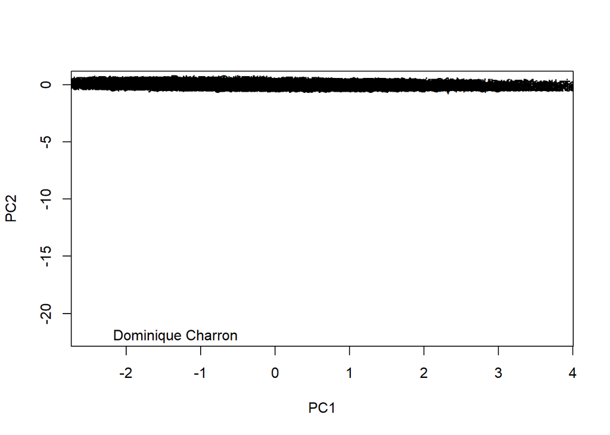

```r
#Hacemos que ironman_numeric sea un dataframe para poder poner los nombres
ironman_numeric <- as.data.frame(ironman_numeric)
rownames(ironman_numeric) <- ironman_lake_placid_female_2022$Name

plot(prcomp(ironman_numeric,scale=T)$x[,1:2], type='n')
text(prcomp(ironman_numeric,scale=T)$x[,1:2],labels=rownames(ironman_numeric))
```

Como podemos leer, la atleta con valores extremos es Dominique Charron:

```r
ironman_lake_placid_female_2022[ironman_lake_placid_female_2022$Name == "Dominique Charron", c("Run.Time", "Bike.Time", "Swim.Time")]
```

```
## # A tibble: 1 × 3
##   Run.Time Bike.Time Swim.Time
##      <dbl>     <dbl>     <dbl>
## 1     306.      433.      3498
```

```r
colMeans(ironman_lake_placid_female_2022[, c("Run.Time", "Bike.Time", "Swim.Time")], na.rm = TRUE)
```

```
##  Run.Time Bike.Time Swim.Time
##  324.5799  424.7561   88.1032
```

Comparándolo con la media de las columnas, la media del valor de Swim.time es 88,1032 y sin embargo, el valor de Swim.Time de Dominique Charron es 3498, por lo que es un valor atípico y su punto en el gráfico se aleja significativamente del resto, vamos a probar a representarlo quitando a esta atleta:

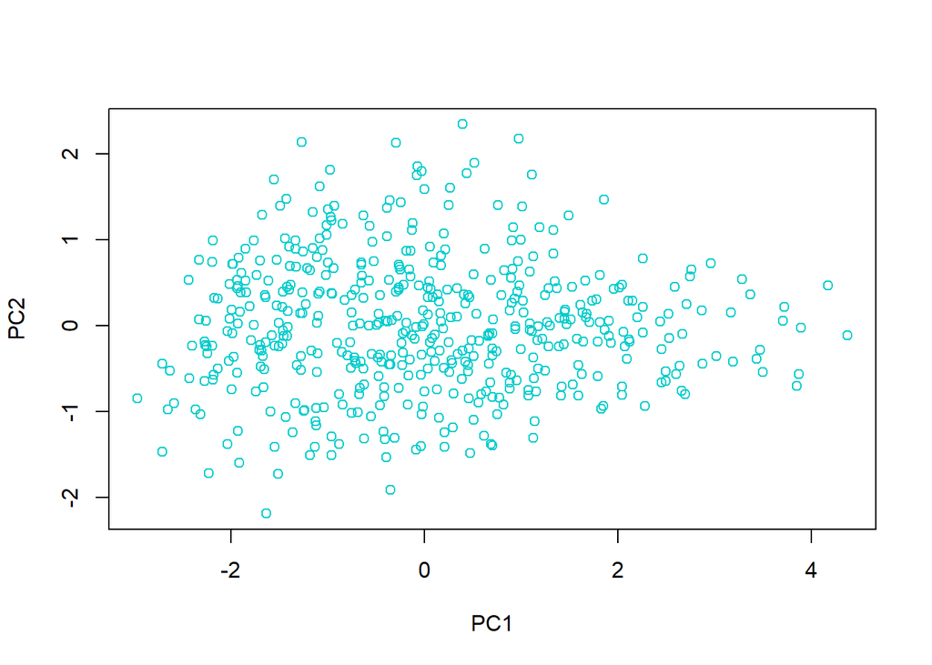

```r
# Eliminar la fila 183
ironman_numeric <- ironman_numeric[-183, ]
plot(-prcomp(ironman_numeric, scale=T)$x[,1:2], col = adjustcolor("cyan3"))
```

Podemos observar una tendencia a la agrupación en la zona central, por lo que interpretamos que la mayoría de atletas tienen un rendimiento similar entre ellas. Sin embargo, también hay ciertos puntos más alejados de la zona central y por tanto más lejos del resto. Esto nos sugiere que hay atletas con un rendimiento diferenciable, pero sin valores extremadamente alejados como era el caso de Dominique Charron. No podemos observar una separación clara en distintos grupos, pero los valores más cercanos entre ellos tendrán un rendimiento similar.

Además, tal y como hemos visto en la matriz de rotación, como todas las variables originales, (Bike Time, Swim Time y Run Time) tienen pesos negativos en PC1, cuanto mas a la izquierda en el eje x, que es el correspondiente a PC1, mayor es su tiempo en las disciplinas. Por lo tanto, los valores mas a la izquierda corresponden a atletas mas lentos, veamos cuales son los más destacados:

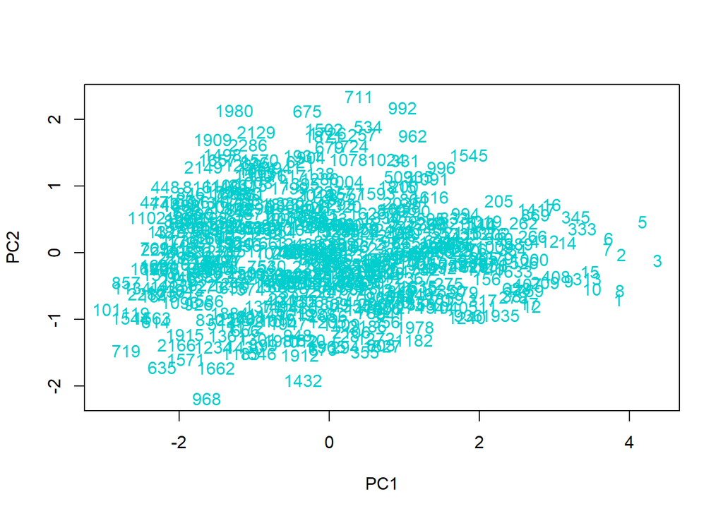

```r
ironman_lake_placid_female_2022 <- ironman_lake_placid_female_2022[-183, ]
rownames(ironman_numeric) <- ironman_lake_placid_female_2022$Bib
plot(-prcomp(ironman_numeric, scale=T)$x[,1:2],type="n")
text(-prcomp(ironman_numeric,scale=T)$x[,1], -prcomp(ironman_numeric, scale=T)$x[,2],rownames(ironman_numeric), col = adjustcolor("cyan3"))
```

Los datos que más a la derecha se encuentran y por tanto deberían ser las atletas más rápidas son los números 3 y 5, vamos a analizar los tiempos de estas atletas en cada una de las disciplinas y ver si efectivamente coincide que sean más rápidas:

```r
ironman_lake_placid_female_2022[ironman_lake_placid_female_2022$Bib == "3", c("Name", "Run.Time", "Bike.Time", "Swim.Time") ]
```

```
## # A tibble: 1 × 4
##   Name       Run.Time Bike.Time Swim.Time
##   <chr>         <dbl>     <dbl>     <dbl>
## 1 Sarah True     184.      296.      55.6
```

```r
#La mas a la derecha
```

```r
ironman_lake_placid_female_2022[ironman_lake_placid_female_2022$Bib == "5", c("Name", "Run.Time", "Bike.Time", "Swim.Time") ]
```

```
## # A tibble: 1 × 4
##   Name             Run.Time Bike.Time Swim.Time
##   <chr>               <dbl>     <dbl>     <dbl>
## 1 Rachel Zilinskas     203.      312.      51.0
```

```r
#La mas a la derecha
```

Media de los tiempos de todas las atletas en cada disciplina:

```r
pca_result$center
```

```
## Swim.Time Bike.Time  Run.Time
##   88.1032  424.7561  324.5799
```

Efectivamente, si lo comparamos con la media de todas las corredoras, Sarah True (3) y Rachel Zilinskas (5) tienen tiempos muy por debajo de la media en las tres disciplinas.

Ahora, realizaremos el mismo análisis para el punto que se encuentra más a la izquierda, que corresponde a la atleta 101.

```r
ironman_lake_placid_female_2022[ironman_lake_placid_female_2022$Bib == "101", c("Name", "Run.Time", "Bike.Time", "Swim.Time") ]
```

```
## # A tibble: 1 × 4
##   Name       Run.Time Bike.Time Swim.Time
##   <chr>         <dbl>     <dbl>     <dbl>
## 1 Megan Hale     414.      478.      109.
```

```r
#La mas a la izquierda
```

Ahora, lo representamos por colores según si ha superado la media en todas las categorías, si no ha superado la media en ninguna y si lo ha superado en algunas si y en otras no, y como podemos observar en el siguiente gráfico coincide con nuestras conclusiones anteriores:

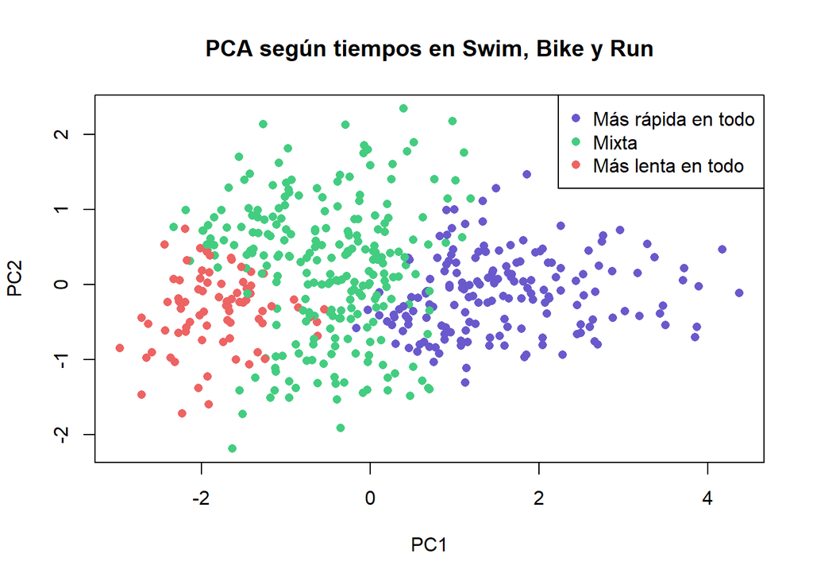

```r
# Calcular el PCA
pca_result <- prcomp(ironman_numeric, scale = TRUE)

# Medias de cada disciplina
media_swim <- 88.1032
media_bike <- 424.7561
media_run  <- 324.5799

swim_times <- ironman_lake_placid_female_2022$Swim.Time
bike_times <- ironman_lake_placid_female_2022$Bike.Time
run_times  <- ironman_lake_placid_female_2022$Run.Time

colores <- ifelse(swim_times < media_swim & bike_times < media_bike & run_times < media_run, "slateblue3",
           ifelse(swim_times > media_swim & bike_times > media_bike & run_times > media_run, "indianred2",
                  "seagreen3"))
plot(-pca_result$x[, 1:2], col = colores, pch = 16,
     xlab = "PC1", ylab = "PC2", main = "PCA según tiempos en Swim, Bike y Run")

# Agregar una leyenda para interpretar los colores
legend("topright", legend = c("Más rápida en todo", "Mixta", "Más lenta en todo"),
       col = c("slateblue3", "seagreen3", "indianred2"), pch = 16)
```

Realizamos un biplot para ver información sobre las variables principales:

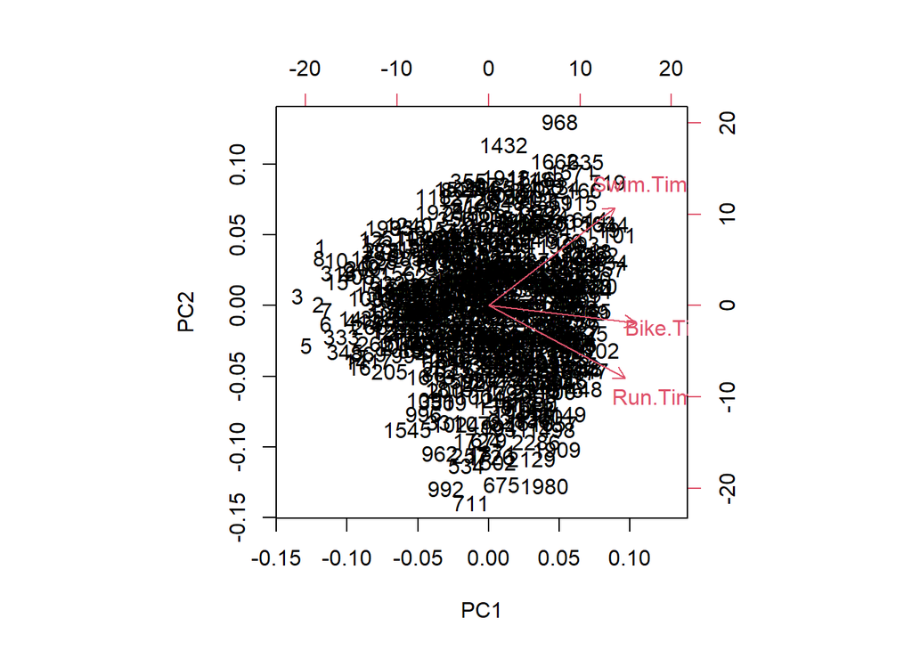

```r
biplot(prcomp(ironman_numeric,scale=T))
```

La variable PC1 ahora muestra valores negativos a la izquierda y positivos a la derecha, con los tiempos de natación, ciclismo y carrera apuntando hacia valores positivos de PC1. Esto indica que los atletas con tiempos más altos en estas disciplinas se encuentran en la parte derecha del gráfico, mientras que los más rápidos (con tiempos menores) están a la izquierda. Además la corredora Sarah True, que como hemos observado anteriormente es corredora rápida, ahora aparece correctamente en el lado izquierdo del gráfico, lo que cofirma la idea de que tiempos más cortos correspondan a valores más bajos en PC1.

Los vectores de Swim.Time, Bike.Time y Run.Time muestran cómo se relacionan las variables originales con los componentes principales e indican la dirección en la que crecen los valores de cada variable.

Los vectores apuntan hacia la derecha, lo que sugiere que valores más altos en estas variables están asociados con valores más altos en PC1. Los tres vectores están relativamente alineados, lo que significa que las tres variables están correlacionadas: una atleta con un tiempo alto en natación probablemente también tenga tiempos altos en ciclismo y carrera.

Nuestros datos proyectados en el nuevo espacio PCA son:

```r
pca_result <- prcomp(ironman_numeric, center = TRUE, scale. = FALSE)
print(head(pca_result$x))
```

```
##          PC1        PC2         PC3
## 3  -192.3677  -6.412705  -6.9364075
## 1  -186.1599 -14.183852   3.1516990
## 8  -183.1102  -1.273207  -0.9581472
## 5  -167.6345  -7.386073 -13.8656847
## 2  -169.3194 -12.931154  -5.9577596
## 10 -166.4725 -13.323771   1.6745028
```

Cada fila es una atleta y cada columna (PC1, PC2 Y PC3) una variable del PCA que son combinaciones lineales de las variables originales. Además, un valor más alto o más bajo en PC1 indica que indica que ese atleta está más alejado del promedio en términos de la variabilidad capturada por ese componente.

## Sin usar ninguna función de R específicamente definida para obtener las componentes principales:

**Matriz de covarianza**: El primer paso para realizar un análisis PCA, es calcular la matriz de covarianza.

```r
#Seleccionamos solo las variables necesarias para hacer el PCA, que son Swim.Time, Bike.Time y Run.Time
ironman_numeric2 <- ironman_lake_placid_female_2022[, c("Swim.Time", "Bike.Time", "Run.Time")]
cov_matrix <- cov(ironman_numeric2)
cov_matrix
```

```
##           Swim.Time Bike.Time  Run.Time
## Swim.Time  127.9210  320.7098  260.3906
## Bike.Time  320.7098 2331.5882 1804.8490
## Run.Time   260.3906 1804.8490 2863.9914
```

**Componentes principales:** El siguiente paso es calcular los autovalores y autovectores usando la matriz de covarianza:

```r
#Usamos la función eigen para sacar la descomposición
eigen_decomp <- eigen(cov_matrix)
```

Sacamos autovalores:

```r
autovalores <- eigen_decomp$values
autovalores
```

```
## [1] 4460.35147  780.96057   82.18857
```

Sacamos autovectores:

```r
autovectores <- eigen_decomp$vectors
autovectores
```

```
##             [,1]       [,2]         [,3]
## [1,] -0.09348814 -0.1033738  0.990239274
## [2,] -0.65201556 -0.7452883 -0.139359279
## [3,] -0.75241988  0.6586799 -0.002274278
```

Los autovalores y autovectores están ordenados de mayor a menor.

**Selección de componentes principales:**

Anteriormente, habiamos ordenado los autovalores y autovectores de mayor a menor, ya que los primeros componentes principales explican la mayor varianza.

Calcularemos la varianza explicada por cada componente principal diviendo cada autovalor por la suma total de autovalores:

```r
varianza_explicada <- autovalores / sum(autovalores)
varianza_explicada
```

```
## [1] 0.83786061 0.14670057 0.01543882
```

La varianza explicada nos muestra el porcentaje de varianza que explica cada componente. Por tanto, la primera componente explica el 83,78% de la varianza, el segundo componente PC2 explica un 14,67% de la varianza y PC3 un 1,5%. Esto ya nos indica que la primera componente principal explica la mayor parte de la varianza y junto con la segunda, ya suman practicamente toda, para verlo aun mas claro, usaremos la varianza acumulada:

```r
varianza_acumulada <- cumsum(varianza_explicada)
varianza_acumulada
```

```
## [1] 0.8378606 0.9845612 1.0000000
```

Esto es simplemente la suma acumulada de la varianza explicada y efectivamente, las dos primeras componentes principales explican un 98,45% de la varianza.

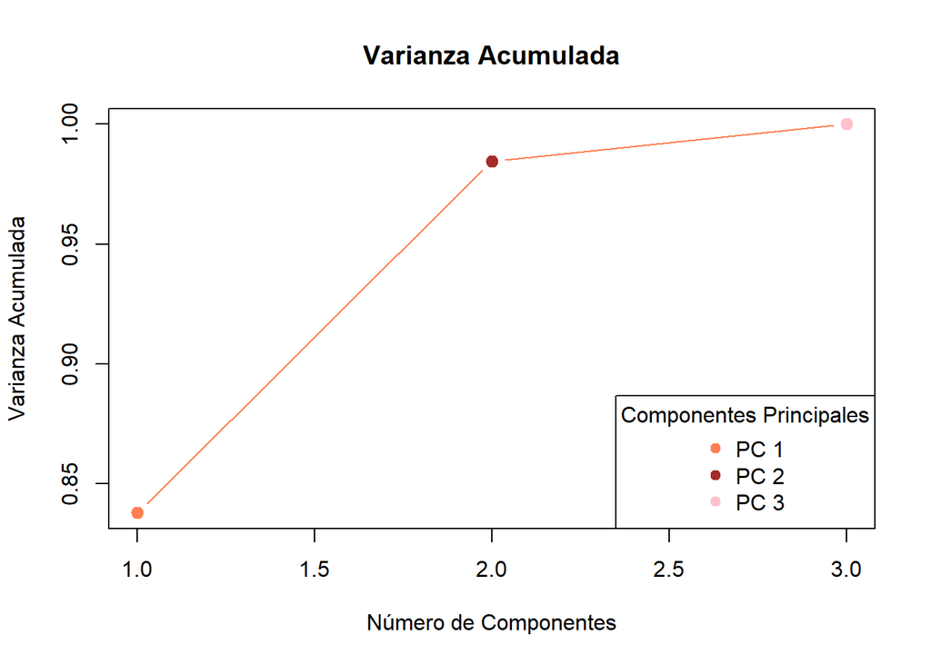

```r
colores <- c("coral", "brown", "pink")

plot(varianza_acumulada, type="b", xlab="Número de Componentes",
     ylab="Varianza Acumulada", main="Varianza Acumulada",
     pch=19, col=colores, cex=1.2)

legend("bottomright", legend=paste("PC", 1:length(varianza_acumulada)),
       col=colores, pch=19, title="Componentes Principales")
```

Usando este gráfico que representa la varianza acumulada por cada componente (que son los puntos) observamos como el primer punto (PC1), explica ya casi un 85% y con el segundo llegan casi a explicar toda la varianza. Si nos fijamos el codo del gráfico (punto donde la pendiente cambia bruscamente) es PC2, por lo que a partir de ahí la siguiente componente no aporta mucha información.

Por tanto, seleccionamos las dos primeras componentes principales, PC1 y PC2, que capturan una cantidad muy significativa de la varianza total.

**Transformación de datos:**

Nuestras variables originales se transforman en un nuevo conjunto de variables, que son las componentes principales, son ortogonales entre sí por lo que no están correlacionadas y capturan la máxima varianza posible de los datos.

Los datos proyectados en el nuevo espacio:

```r
#Aquí centramos los datos restando la media de cada variable
datos_centrados <- scale(ironman_numeric2, center = TRUE, scale = FALSE)

#Multiplicamos la matriz centrada por la matriz de autovectores
datos_pca <- datos_centrados %*% autovectores

# Mostrar los primeros valores transformados
print("Datos proyectados en el nuevo espacio PCA:")
```

```
## [1] "Datos proyectados en el nuevo espacio PCA:"
```

```r
print(head(datos_pca))
```

```
##          [,1]      [,2]        [,3]
## [1,] 192.3677  6.412705  -6.9364075
## [2,] 186.1599 14.183852   3.1516990
## [3,] 183.1102  1.273207  -0.9581472
## [4,] 167.6345  7.386073 -13.8656847
## [5,] 169.3194 12.931154  -5.9577596
## [6,] 166.4725 13.323771   1.6745028
```

Cada columna es una componente principal y cada fila es una observación, esto es lo equivalente a la operación **(pca_result$x)** con prcomp() que hemos realizado en el apartado anterior:

```r
pca_result <- prcomp(ironman_numeric, center = TRUE, scale. = FALSE)
print(head(pca_result$x))
```

```
##          PC1        PC2         PC3
## 3  -192.3677  -6.412705  -6.9364075
## 1  -186.1599 -14.183852   3.1516990
## 8  -183.1102  -1.273207  -0.9581472
## 5  -167.6345  -7.386073 -13.8656847
## 2  -169.3194 -12.931154  -5.9577596
## 10 -166.4725 -13.323771   1.6745028
```

Ambos representan la proyección de los datos en el nuevo espacio y el resultado es el mismo. La única diferencia son los signos de PC1 Y PC2, que son contrarios en la primera y segunda representación, pero esto se debe a que los autovectores pueden tener la dirección invertida sin alterar la varianza explicada ni la relación entre los datos.

Si representamos los datos proyectados en el espacio de PC1 Y PC2 obtenemos:

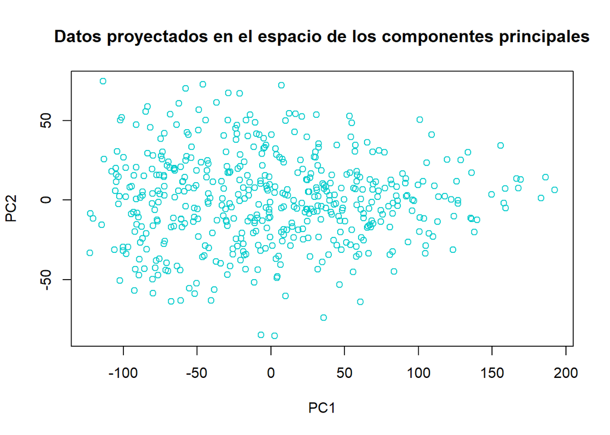

```r
plot(datos_pca[,1:2], xlab="PC1", ylab="PC2",
     main="Datos proyectados en el espacio de los componentes principales", col = adjustcolor("cyan3"))
```

Comparándolo con la representación de hecha con prcomp():

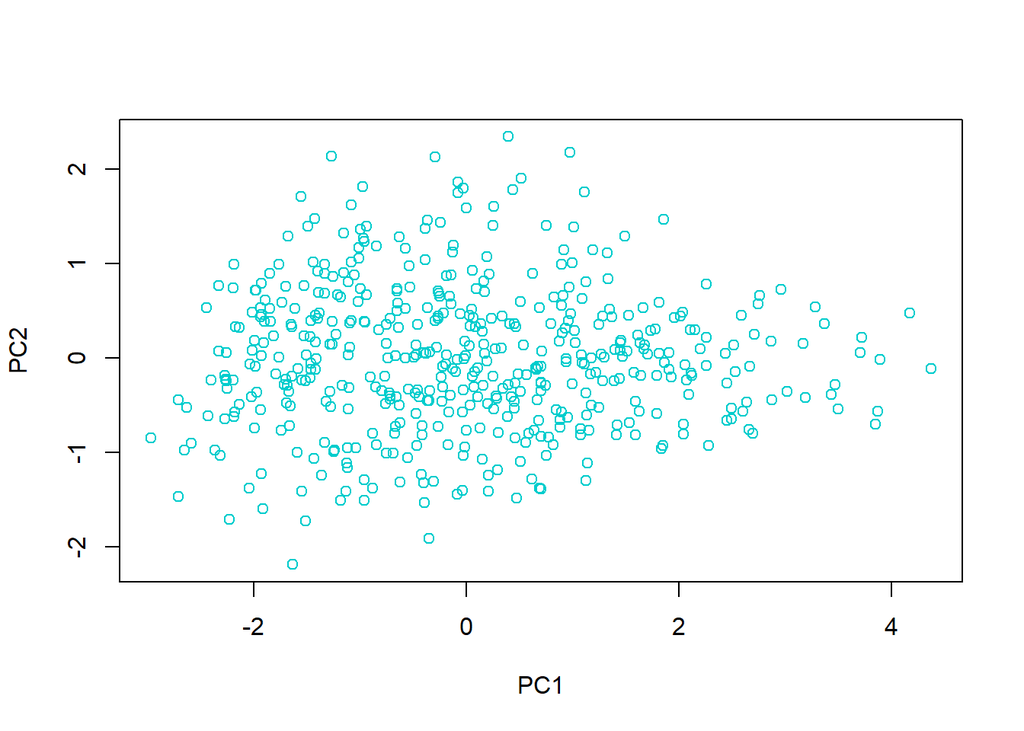

```r
# Eliminar la fila 183
ironman_numeric <- ironman_numeric[-183, ]
plot(-prcomp(ironman_numeric, scale=T)$x[,1:2], col = adjustcolor("cyan3"))
```

Las principales diferencias entre las representaciones son dos, la escala de los ejes que se debe a la funcion scale = T de la función prcomp() que ha normalizado las variables antes de calcular el PCA. La otra diferencia es la distribución de los puntos, pero a pesar de no ser iguales están distribuidos de manera similar, esto también puede deberse a la diferencia en el escalado, veamos que ocurre si lo representamos con prcomp() pero sin scale=T:

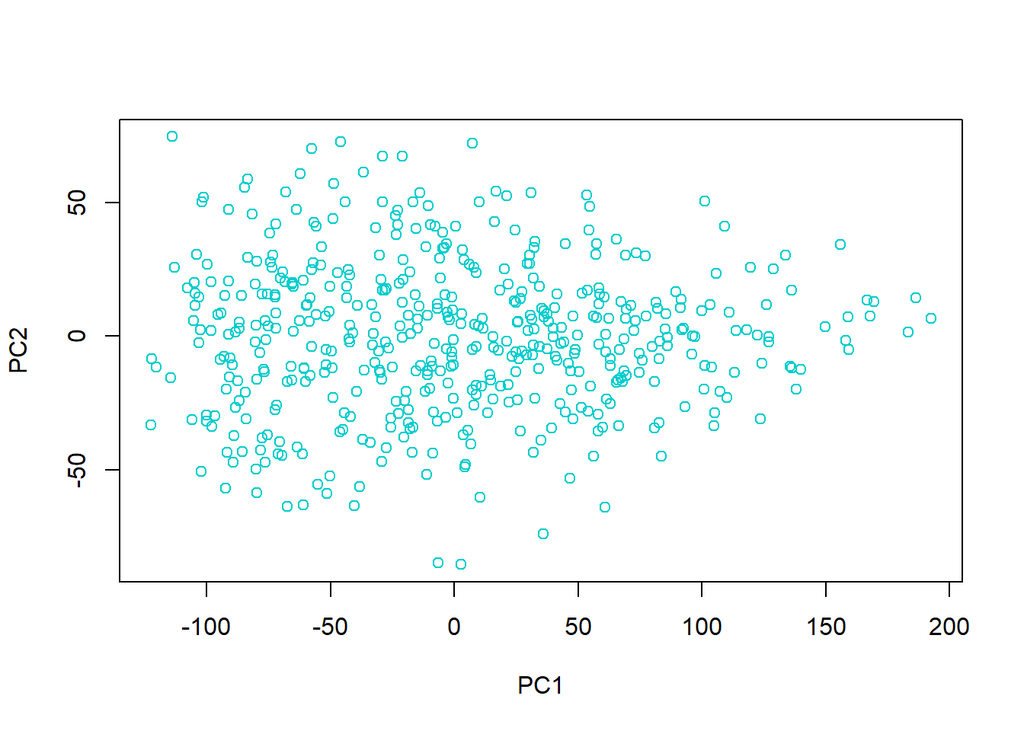

```r
# Eliminar la fila 183
ironman_numeric <- ironman_numeric[-183, ]
plot(-prcomp(ironman_numeric)$x[,1:2], col = adjustcolor("cyan3"))
```

Representándolo de esta manera la distribución es exactamente igual que la que hemos obtenido programando a mano. Por tanto, las conclusiones obtenidas del PCA son las mismas ya que hemos llegado al mismo resultado.

El PCA nos ha permitido reducir la dimensión de los datos de rendimiento en el Ironman, transformando las variables originales en componentes explicativas, de las cuales PC1 Y PC2 han sido suficientemente explicativas. Por su parte, PC1 ha explicado la mayor parte de la variabilidad, indicandonos que los tiempos de nadar, correr y bicicleta están correlacionados.

# 4. Aprendizaje no supervisado.

## Matriz de distacias o semejanzas.

Vamos a diseñar una matriz de distancias según las características de nuestros datos.

En el EDA ya hemos visto como tenemos tanto datos numéricos como datos categóricos. Es por eso que calcular una matriz de distancias euclidiana no es buena idea ya que se necesitan datos numéricos y apenas la mitad de nuestros datos lo son, por lo que la mejor matriz de distancias que se ajusta más a nuestros datos, dado que tenemos tanto de tipo categóricas y continuas, es hacer la **matriz de distancias de Gower**.

Antes de crear la matriz vamos a transformar las variables de tipo cadena de caracteres a factor para evitar posibles errores.

```r
library(corrplot)
# Cambiar variables de tipo cadena de caracteres a factor.
train <- train |>
  mutate(across(where(is.character), as.factor))

# Matriz de distancias.
M_dist <- as.matrix(daisy(train, metric = "gower"))
```

## Comprobar si cumple las condiciones para ser una métrica o una medida de desemejanza

Si, además, la función $\delta(x, y)$ verifica la desigualdad triangular, se trataría de una distancia :

$$\delta(x, y) \leq \delta(x, z) + \delta(y, z)$$

```r
# Verificar si la matriz de Gower cumple las condiciones para ser una métrica

# 1. No negatividad
no_negatividad <- all(M_dist >= 0)

# 2. Identidad del indiscernible
identidad_indiscernible <- all(diag(M_dist) == 0)

# 3. Simetría
simetria <- all(M_dist == t(M_dist))

print(no_negatividad, identidad_indiscernible, simetria)
```

```
## [1] TRUE
```

Ahora vamos a ver si cumple la desigualdad triangular:

```r
n <- nrow(M_dist)

# Verificación de la desigualdad triangular
desigualdad_triangular <- TRUE

for (i in 1:n) {
  for (j in 1:n) {
    for (k in 1:n) {
      if (M_dist[i, k] > M_dist[i, j] + M_dist[j, k]) {
        desigualdad_triangular <- FALSE
        break
      }
    }
    if (!desigualdad_triangular) break
  }
  if (!desigualdad_triangular) break
}

# Imprimir resultado
if (desigualdad_triangular) {
  print("La matriz de Gower cumple la desigualdad triangular (es una métrica).")
} else {
  print("La matriz de Gower NO cumple la desigualdad triangular (no es una métrica).")
}
```

```
## [1] "La matriz de Gower NO cumple la desigualdad triangular (no es una métrica)."
```

Dado que las 3 primeras condiciones las cumple y la desigualdad triangular no, entonces **no es una métrica**, pero **sí es una medida de desemejanza**

# Métodos no jerárquicos

Primero, vamos a usar el método de las k-medias.

El método de las k-medias es de los algoritmos de Machine Learning más utilizado para la agrupación de observaciones en un conjunto de k clústeres. Don de k es un valor que hay que fijarlo de antemano.

Vamos a usar la matriz de Gower que hemos calculado antes.

### Número óptimo de clusters

**- El método del codo**

Según este método, el número mas óptimo de clusters es cuando se da un cambio abrupto en la pendiente de la función

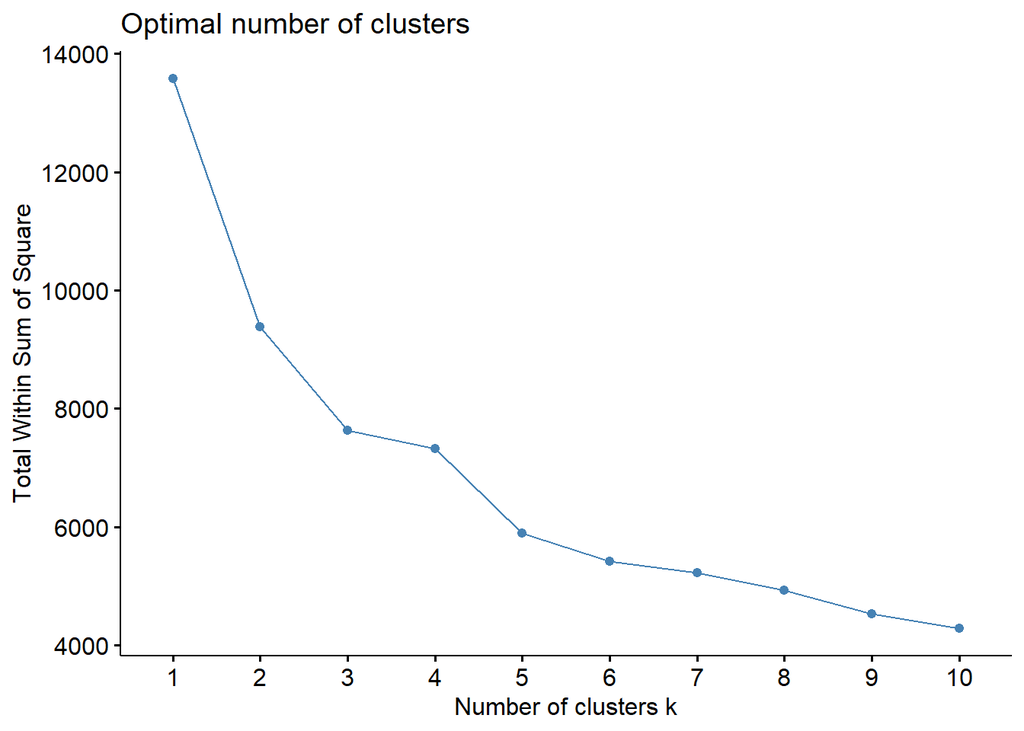

```r
fviz_nbclust(M_dist, kmeans, method = "wss")
```

**- Método de la silueta**

Este método nos ayuda a valorar la coherencia (o calidad) de los resultados de los clusters, es decir, determina hasta qué punto cada observacion se encuentra correctamente ubicada dentro de su agrupación.

Este algoritmo nos señala con una línea discontinua vertical el número mas óptimo

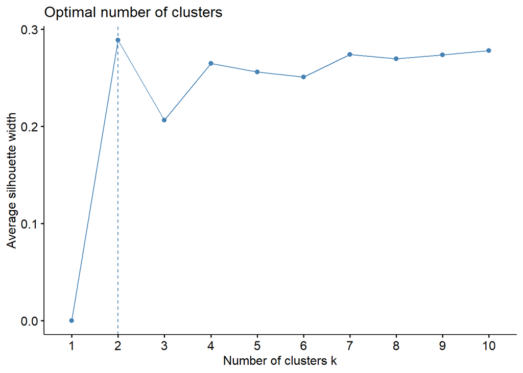

```r
fviz_nbclust(M_dist, kmeans, method = "silhouette")
```

Este algoritmo nos dice que **el número óptimo de clusters es 2**.

Para confirmar lo que nos dice este método, vamos a comprobar si haciendo el algoritmo de las k-medias con 2 centros (2 clusters) nos puede dar una buena agrupacion interpretando el gráfico de siluetas.

```
##   cluster size ave.sil.width
## 1       1  806          0.35
## 2       2  460          0.17
```

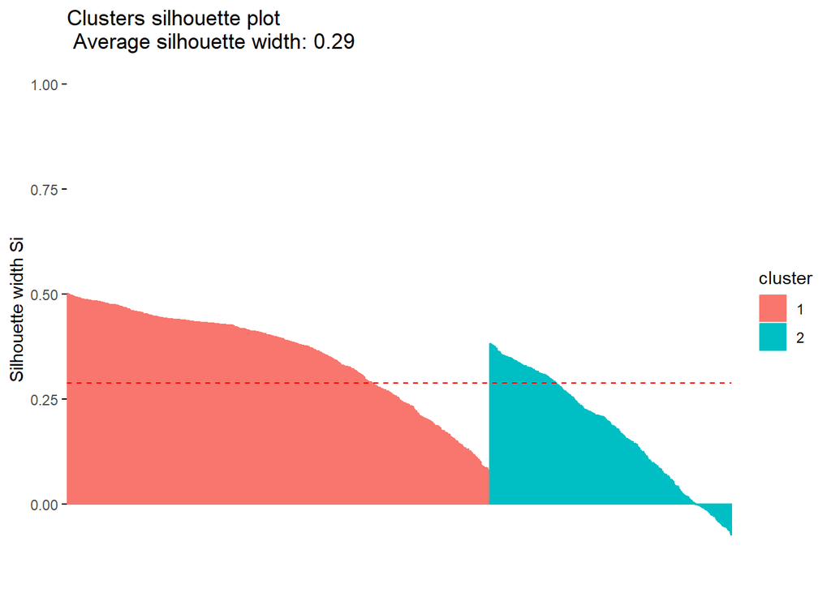

```r
# k-medias con 2 centros
k2 <- kmeans(M_dist, centers = 2, nstart = 50)

# Gráfica de siluetas
sil <- silhouette(k2$cluster, dist (M_dist))
fviz_silhouette(sil)
```

Para interpretar el gráfico, hay que fijarse en los valores positivos y negativos. Aquellos que sean mas próximos a 1, es que la observación está bien agrupada, mientras que cuando esté mas cerca de 0 es que está mal agrupada.

Ahora, analizando la gráfica que tenemos, podemos concluir que **una aproximacion de 2 clusters es óptima**, a pesar de que uno de los dos grupos tengan valores negativos

Dado que con estos métodos nos ha dado que el número óptimo de clusters es 2, vamos a hacer k-means son 2 clusters:

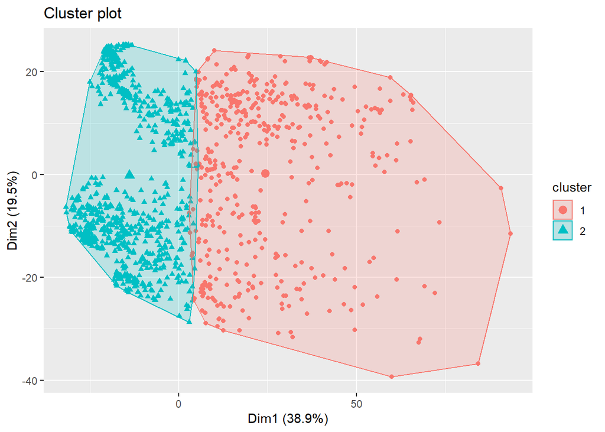

```r
k2 <- kmeans(M_dist, centers = 2, nstart = 50)

fviz_cluster(k2, data = M_dist, geom = "point")
```

```r
k2$withinss
```

```
## [1] 4440.883 4948.669
```

```r
k2$totss
```

```
## [1] 13574.93
```

```r
k2$betweenss
```

```
## [1] 4185.379
```

Por lo que nos da a entender que los dos clusters están medianamente igualados.

## Métodos jerárquicos

### Cluster Jerárquico Aglomerativo

Primero vamos a entender este tipo de cluster jerárquico.

Se empieza con n conglomerados, uno por cada dato y en cada paso se van fusionando los 2 grupos más similares, hasta que llega a un punto en que se queda en un solo grupo que contiene a todos.

Primero vamos a ver el coeficiente aglomerativo. Cuanto mas cercano a 1, más fuerte es el agrupamiento. Para tener más opiniones sobre qué tipo de método usar, vamos a ver el coeficiente aglomerativo de 4 métodos: Average, Single, Complete, Ward

```r
m <- c( "average", "single", "complete", "ward")
names(m) <- c( "average", "single", "complete", "ward")

# Función para calcular el coeficiente de agrupamiento
ac <- function(x) {
  agnes(M_dist, method = x)$ac
}

map_dbl(m, ac)
```

```
##   average    single  complete      ward
## 0.8836509 0.8116313 0.9378407 0.9907047
```

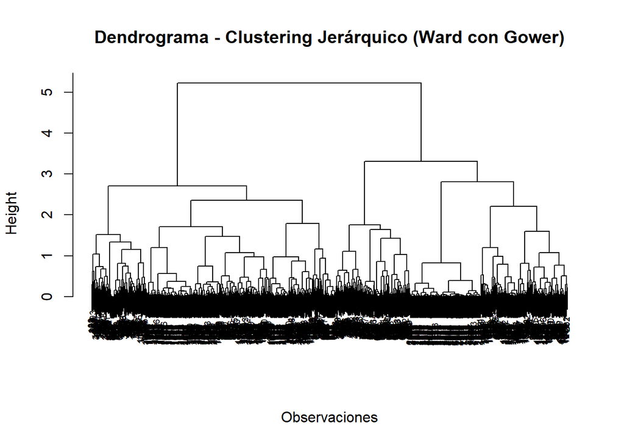

```r
# Convertir la matriz de Gower a formato 'dist'
M_dist <- as.dist(as.matrix(M_dist))

# Aplicar MDS para convertir en formato euclidiano
hc1 <- cmdscale(M_dist, k = 2)

# Realizar clustering jerárquico con método Ward
hc1 <- hclust(M_dist, method = "ward.D2")

# Graficar el dendrograma
plot(hc1, main = "Dendrograma - Clustering Jerárquico (Ward con Gower)",
     xlab = "Observaciones", sub = "", cex = 0.6)
```

Es fácil ver que el número mas óptimo, otra vez, es de **2 clusters**. Vamos a representar el corte que habría qeu hacer para separar el dendograma en 2 grupos:

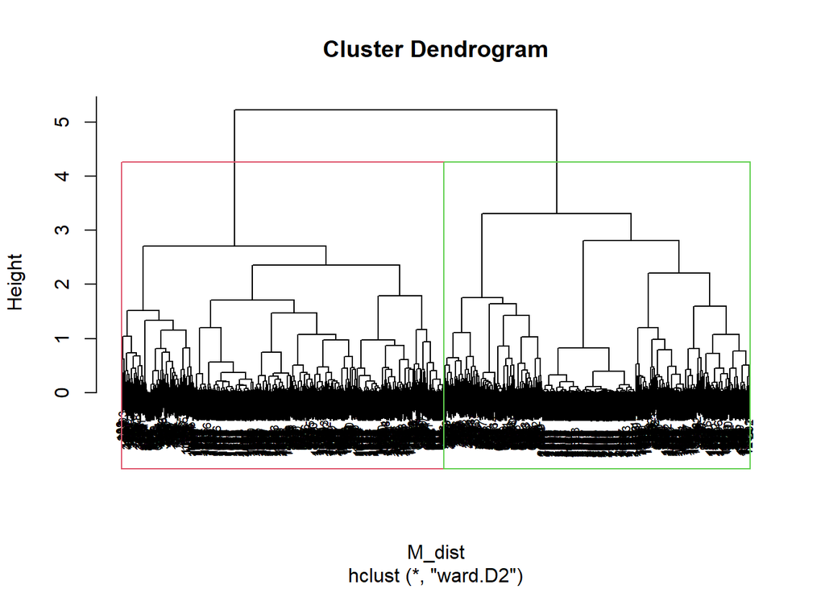

```r
# Cortamos en 2 clusters
sub_grp <- cutree(hc1, k = 2)

# Visualizamos el corte en el dendrograma
plot(hc1, cex = 0.6)
rect.hclust(hc1, k = 2, border = 2:5)
```

A continuación, vamos a explicar los grupos visualizando la media de cada grupo por cada variable.

```r
# Agregamos los clusters al dataframe original
train$Cluster <- as.factor(k2$cluster)

# Hacemos la media de cada variable por cluster
cluster_means <- train %>%
  group_by(Cluster) %>%
  summarise(across(where(is.numeric), mean, na.rm = TRUE))
```

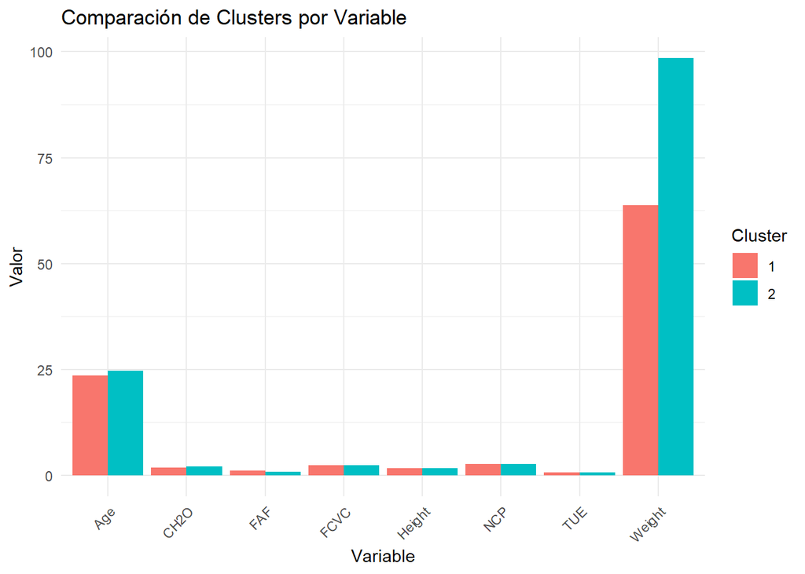

```r
# Convertimos a formato largo para graficar
cluster_long <- pivot_longer(cluster_means, cols = -Cluster, names_to = "Variable", values_to = "Valor")

# Hacemos una gráfica de barras para comparar las variables por cluster
ggplot(cluster_long, aes(x = Variable, y = Valor, fill = Cluster)) +
  geom_bar(stat = "identity", position = "dodge") +
  theme_minimal() +
  labs(title = "Comparación de Clusters por Variable", x = "Variable", y = "Valor") +
  theme(axis.text.x = element_text(angle = 45, hjust = 1))
```

# 5. Conclusiones.

Hemos analizado un conjunto de datos de obesidad de México, Perú y Colombia y así poder caracterizar los distintos niveles de obesidad según diversas variables.

Utilizando varias técnicas de exploracion de datos, reduccion de dimensionalidad y aprendizaje no supervisado para realizar un análisis de los factores asociados a la obesidad en los individuos.

En este análisis hemos podido identificar ciertas relaciones entre variables como el peso, altura, edad, historial familiar de sobrepeso, actividad fisica y otros factores.

Las principales conclusiones que hemos podido obtener han sido:

En definitiva, este estudio resalta la importancia de llevar un estilo de vida saludable, evidenciando que una alimentación equilibrada, la actividad física regular y la reducción del sedentarismo son elementos fundamentales para prevenir y controlar la obesidad.

Partes de la práctica realizada por cada miembro del grupo: - 1. Comprensión del problema: Marcos López García - 2. EDA: Marcos López García y Carmen Liberal Jiménez - 3. PCA: Carmen Liberal Jiménez - 4. Matriz de distancias: Marcos López García. Condiciones de métrica y clustering: Lara Montero del Prado - 5. Conclusión: Lara Montero del Prado